# Linear Algebra for Data Science, Part 2

PSTAT 134 (Winter 2026)

Author

Affiliation

Sang-Yun Oh

University of California, Santa Barbara

## Interpretation of Data Representation 1

Suppose $\mathbf{X}=\mathbf{Q} \mathbf{V}^\top$ and is a rank factorization of data matrix $\mathbf{X}$.

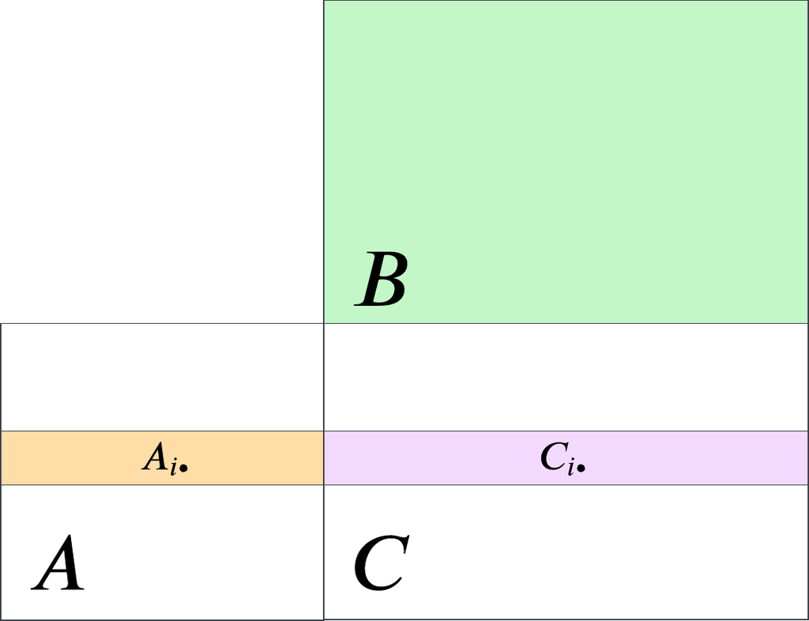

$$\mathbf{X}_{i\bullet} = \mathbf{Q}_{i\bullet} \mathbf{V}^\top$$

- $\mathbf{Q}$ is an $n \times k$ matrix, where $n$-individuals and $k$-latent features.
- $\mathbf{V}$ is a $p \times k$ matrix, where $p$-variables and $k$-latent features.

. . .

- Each row of $\mathbf{Q}$ is one individual in $k$-dimensional latent feature space.
- Mult. by $\mathbf{V}^\top$ transforms an individual to observed variable space.
- Latent individual features and basis vectors reconstruct the observed data of the individual.

## Interpretation of Data Representation 2

Suppose $\mathbf{X}=\mathbf{Q} \mathbf{V}^\top$ and is a rank factorization of data matrix $\mathbf{X}$.

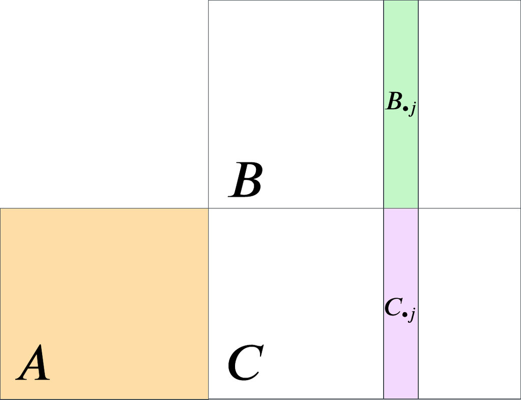

- $\mathbf{Q}$ is an $n \times k$ matrix, where $n$-individuals and $k$-latent features.
- $\mathbf{V}$ is a $p \times k$ matrix, where $p$-variables and $k$-latent features.

. . .

- A row of $\mathbf{V}$ represent components of basis vectors that contributes to a single variable $j$.
- Together with all latent individual features in $\mathbf{Q}$, we can reconstruct the observed data of variable $j$.

## Interpretation of Data Representation 3

Suppose $\mathbf{X}=\mathbf{Q} \mathbf{V}^\top$ and is a rank factorization of data matrix $\mathbf{X}$.

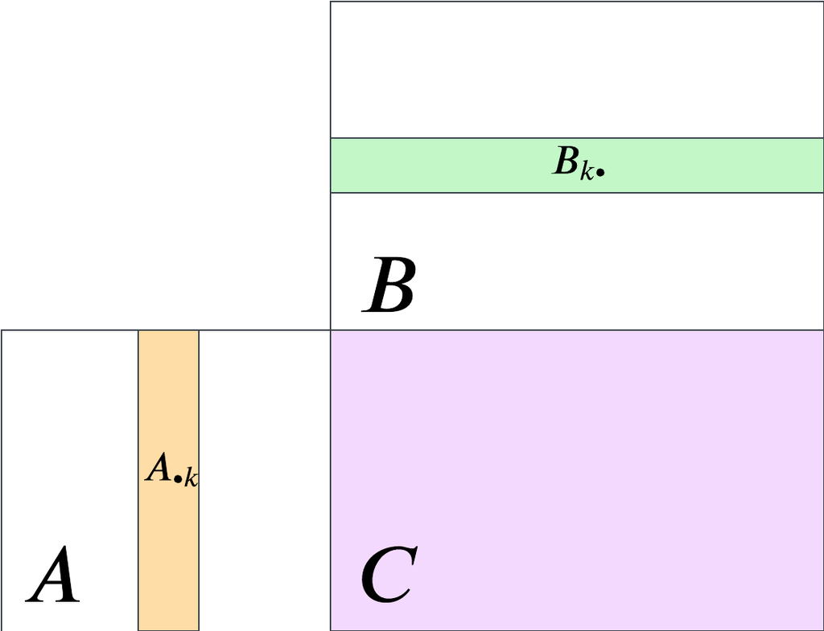

- $\mathbf{Q}$ is an $n \times k$ matrix, where $n$-individuals and $k$-latent features.
- $\mathbf{V}$ is a $p \times k$ matrix, where $p$-variables and $k$-latent features.

. . .

## PCA: Visualizing Latent Feature Contributions

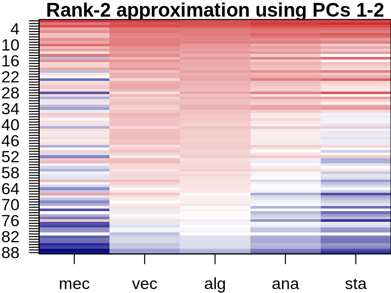

$\hat{X} \qquad \approx$

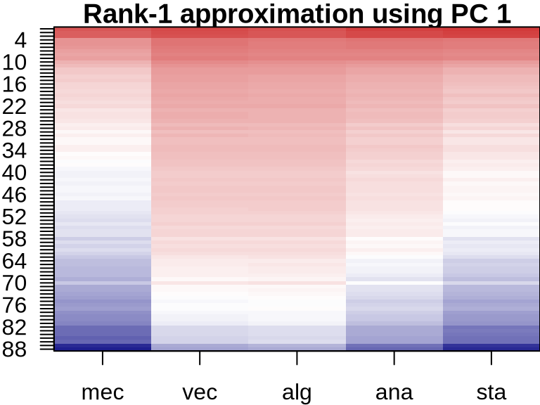

$Q_{\bullet 1}(V_{\bullet 1})'\qquad+$

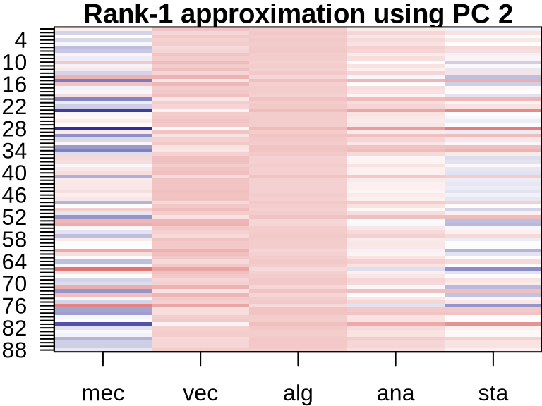

$Q_{\bullet 2}(V_{\bullet 2})'$

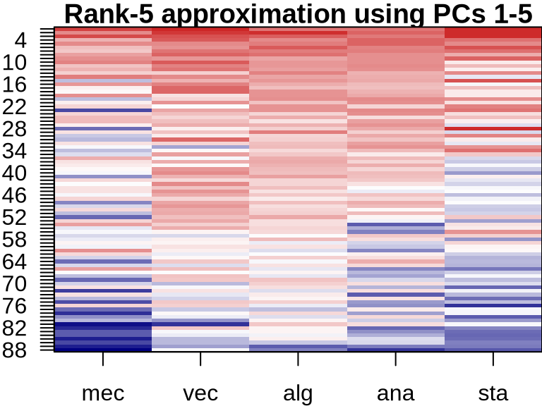

$\hat{X} \qquad \approx$

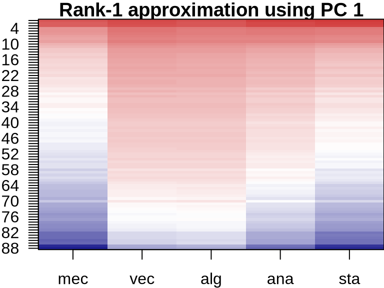

$Q_{\bullet 1}(V_{\bullet 1})'\qquad+$

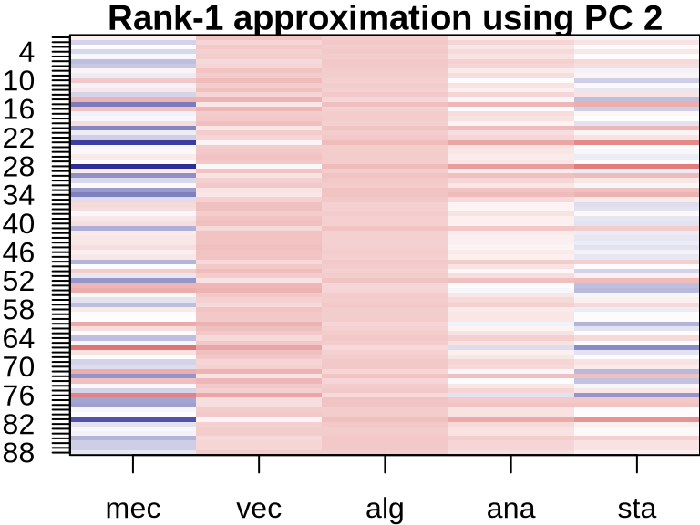

$Q_{\bullet 2}(V_{\bullet 2})'\qquad+$

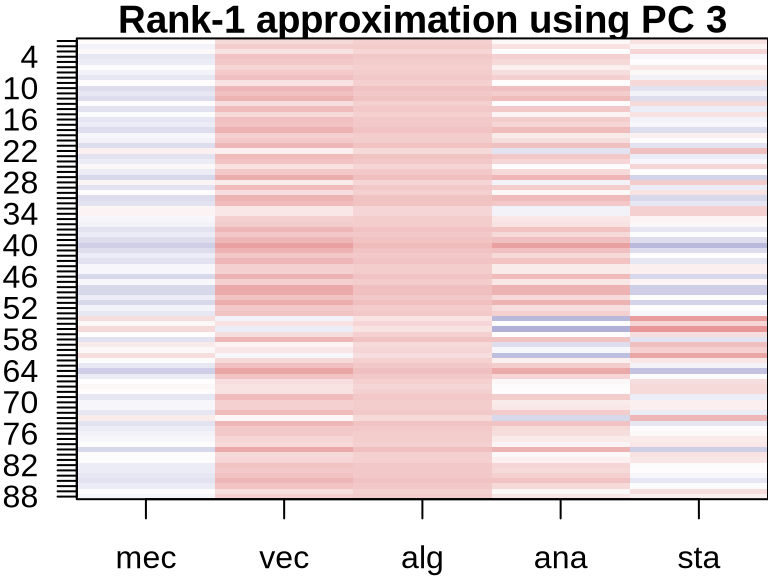

$Q_{\bullet 3}(V_{\bullet 3})'\quad+$

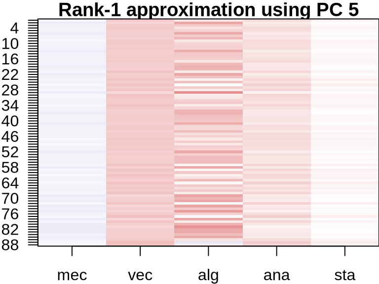

$\cdots + Q_{\bullet 5}(V_{\bullet 5})'$

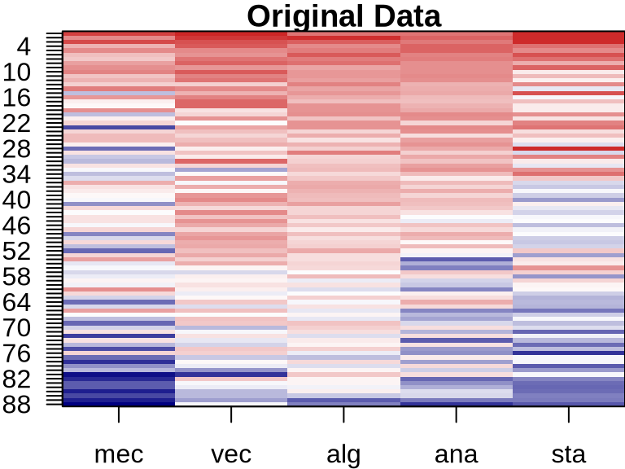

$X - \hat{\mu}$

## NMF: Visualizing Latent Feature Contributions

[output not shown]

[output not shown]

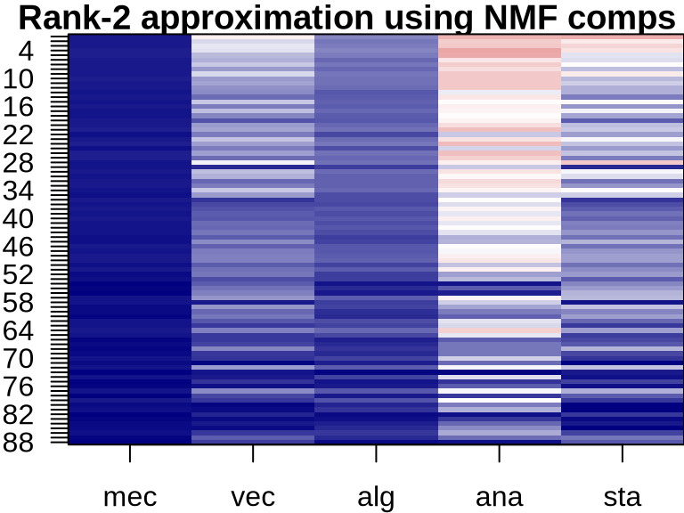

$\hat{X} \qquad \approx$

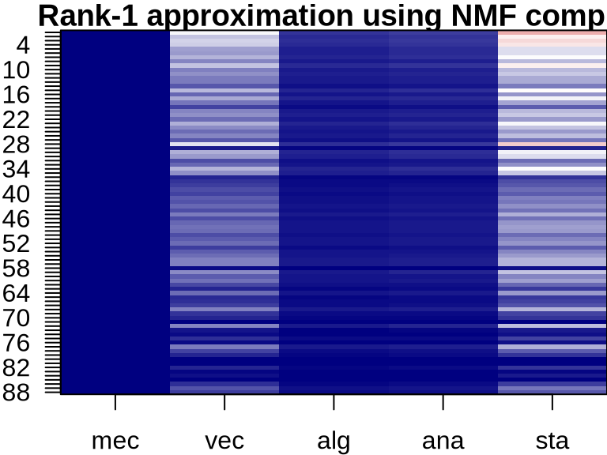

$Q_{\bullet 1}(V_{\bullet 1})'\qquad+$

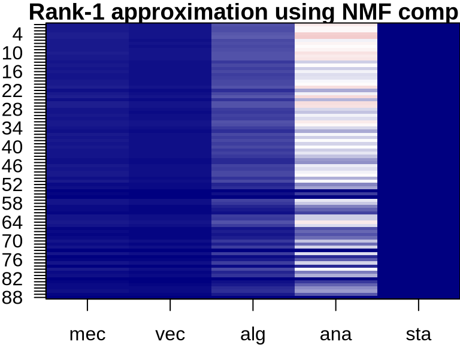

$Q_{\bullet 2}(V_{\bullet 2})'$

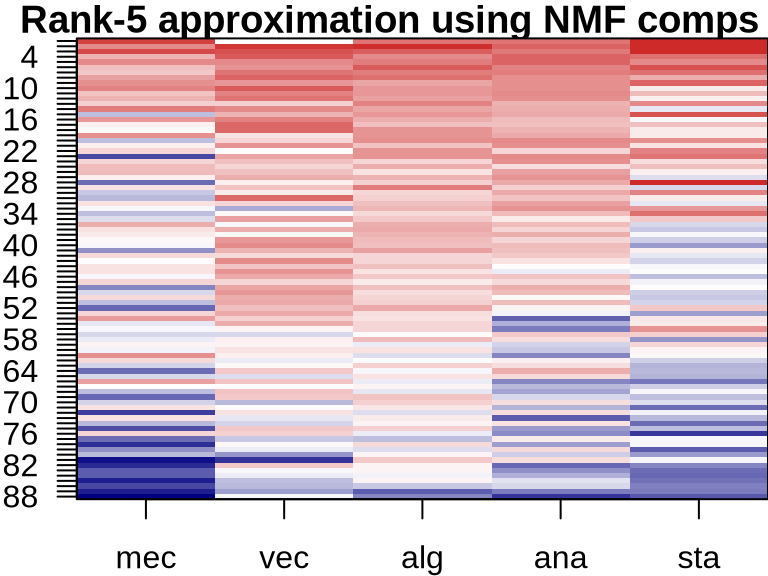

$\hat{X} \qquad \approx$

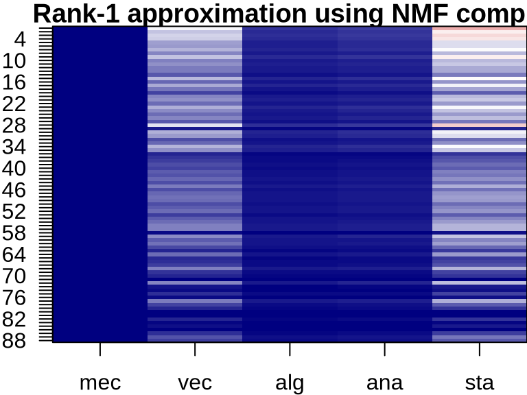

$Q_{\bullet 1}(V_{\bullet 1})'\qquad+$

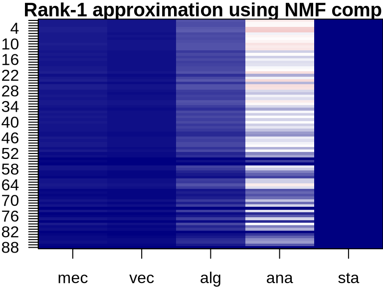

$Q_{\bullet 2}(V_{\bullet 2})'\qquad+$

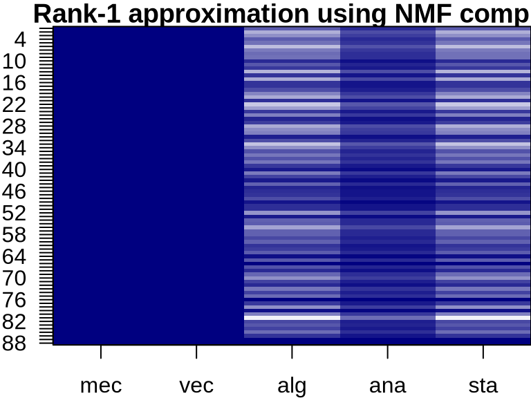

$Q_{\bullet 3}(V_{\bullet 3})'\qquad+$

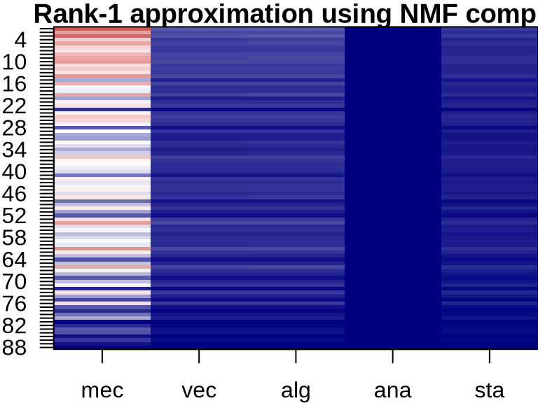

$\cdots + Q_{\bullet 5}(V_{\bullet 5})'$

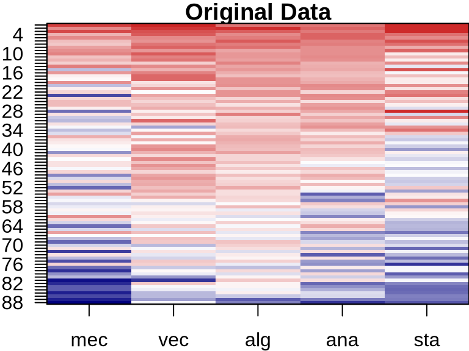

$X$

## Covariance Matrix is a Gram Matrix

**Definition 4.10: Gram Matrix**

Definition 4.10. Let $\mathbf{v}_1, \ldots, \mathbf{v}_k \in \mathbb{R}^n$. The associated Gram matrix

$$G=\left(\begin{array}{cccc}
\left\langle\mathbf{v}_1, \mathbf{v}_1\right\rangle & \left\langle\mathbf{v}_1, \mathbf{v}_2\right\rangle & \ldots & \left\langle\mathbf{v}_1, \mathbf{v}_k\right\rangle \\
\left\langle\mathbf{v}_2, \mathbf{v}_1\right\rangle & \left\langle\mathbf{v}_2, \mathbf{v}_2\right\rangle & \ldots & \left\langle\mathbf{v}_2, \mathbf{v}_k\right\rangle \\
\vdots & \vdots & \ddots & \vdots \\
\left\langle\mathbf{v}_k, \mathbf{v}_1\right\rangle & \left\langle\mathbf{v}_k, \mathbf{v}_2\right\rangle & \ldots & \left\langle\mathbf{v}_k, \mathbf{v}_k\right\rangle
\end{array}\right)$$

is the $k \times k$ matrix whose entries are the inner products between the selected vectors.

. . .

Sample covariance matrix $G = \mathbf{X}^\top \mathbf{X}/n$ is a Gram matrix of the column vectors of $\mathbf{X}$ scaled by $1/n$ (assume zero-centered data).

## Properties of Gram Matrices

**Theorem 4.12: Positivity of Gram Matrices**

All Gram matrices are positive semidefinite. The Gram matrix is positive definite if and only if $\mathbf{v}_1, \ldots, \mathbf{v}_k$ are linearly independent.

. . .

**Theorem 4.13: Rank and Kernel of Gram Matrix**

Suppose $A$ is an $n \times k$ matrix. If $K$ is any positive definite $n \times n$ matrix, then the Gram matrix $G=A^T K A$ is a positive semidefinite $k \times k$ matrix, and is positive definite if and only if $\operatorname{rank} A=k$. In general, $\operatorname{ker} G=\operatorname{ker} A$, and hence $\operatorname{rank} G=\operatorname{rank} A$.

. . .

If all column vectors of $X$ are linearly independent (vs. dependent), then $\operatorname{rank} X=p$ (vs. $\operatorname{rank} X<p$) and Gram matrix $G=X^T X/n$ is positive definite (vs. positive semidefinite but not positive definite).

## Properties of $A$ and Linear Systems

Consider a linear system $A \mathbf{x}=\mathbf{b}$ for $\mathbf{b} \in \mathbb{R}^p$.

. . .

Suppose $A = \mathbf{X}^\top \mathbf{X}/n$ is a $p\times p$ sample covariance matrix. And $\mathbf{b} = \mathbf{X}^\top \mathbf{y}/n$ for response vector $\mathbf{y} \in \mathbb{R}^n$.

. . .

**Definition 3.11: Nonsingular Matrix**

Let $A$ be a square $n \times n$ matrix. Then $A$ is said to be nonsingular if its rank is maximal, namely $\operatorname{rank} A=n$.

**Theorem 3.13: Rank of Transpose**

Let $A$ be a matrix. Then

$$\operatorname{rank} A=\operatorname{rank} A^T .$$

As a consequence, $0 \leq \operatorname{rank} A \leq \min \{m, n\}$

## Equivalent Conditions for Nonsingularity

**Theorem 3.12: Equivalent Conditions for Nonsingularity**

Let $A$ be a square $n \times n$ matrix. Then the following are equivalent:

1. $A$ is nonsingular;
2. $\operatorname{rank} A=n$;
3. $\operatorname{nullity} A=0$;
4. $\operatorname{img} A=\mathbb{R}^n$;
5. $\operatorname{ker} A=\{\mathbf{0}\}$.

. . .

**Theorem 3.17: Solutions to Linear Systems**

Let $A$ be an $m \times n$ matrix. Then the linear system $A \mathbf{x}=\mathbf{b}$ for $\mathbf{b} \in \mathbb{R}^m$ is compatible, and so has a solution $\mathbf{x}^{\star} \in \mathbb{R}^n$ if and only if $\mathbf{b} \in \operatorname{img} A$. Moreover, the general solution to the system is given by $\mathbf{x}=\mathbf{x}^{\star}+\mathbf{z}$ where $\mathbf{z} \in \operatorname{ker} A$ is an arbitrary element of the kernel of the coefficient matrix.

. . .

**Theorem 3.18: Solutions to Linear Systems**

A system $A \mathbf{x}=\mathbf{b}$ has either

1. exactly one solution, when $\mathbf{b} \in \operatorname{img} A$ and $\operatorname{nullity} A=0$, or
2. infinitely many solutions, when $\mathbf{b} \in \operatorname{img} A$ and $\operatorname{nullity} A>0$, or
3. no solutions when $\mathbf{b} \notin \operatorname{img} A$.

## Norms and Inner Products Review

**Definition 2.34: Norm**

Definition 2.34. A norm on $\mathbb{R}^n$ assigns a nonnegative real number $\|\mathbf{v}\|$ to each vector $\mathbf{v} \in \mathbb{R}^n$, subject to the following axioms, valid for every $\mathbf{v}, \mathbf{w} \in \mathbb{R}^n$ and $c \in \mathbb{R}$ :

1. Positivity: $\quad\|\mathbf{v}\| \geq 0$, with $\|\mathbf{v}\|=0$ if and only if $\mathbf{v}=\mathbf{0}$.
2. Homogeneity: $\|c \mathbf{v}\|=|c|\|\mathbf{v}\|$.
3. Triangle inequality: $\quad\|\mathbf{v}+\mathbf{w}\| \leq\|\mathbf{v}\|+\|\mathbf{w}\|$.

. . .

**Theorem 2.36: Equivalence of Norms**

Theorem 2.36. Let $\|\cdot\|_a$ and $\|\cdot\|_b$ be any two norms on $\mathbb{R}^n$. Then there exist positive constants $0<r^{\star} \leq R^{\star}$ such that

$$r^{\star}\|\mathbf{v}\|_a \leq\|\mathbf{v}\|_b \leq R^{\star}\|\mathbf{v}\|_a \quad \text { for every } \quad \mathbf{v} \in \mathbb{R}^n .$$

## Equivalence of Norms

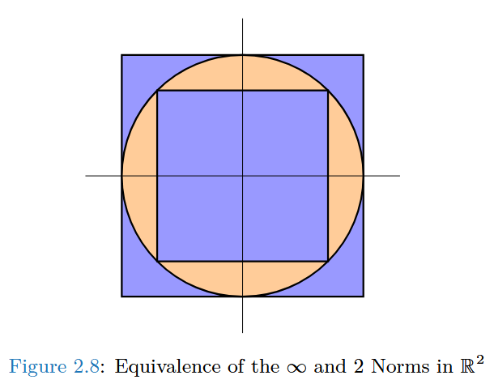

Equivalence of norms

# Applications: Matrix Factorizations

## Various SVD forms

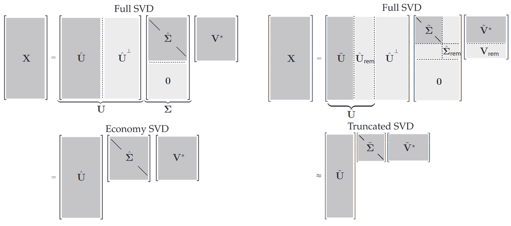

SVD forms (Brunton and Kutz 2019)

## Eigenfaces: Data

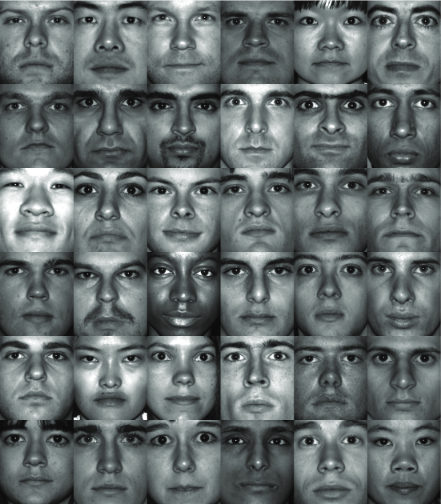

Eigenfaces example data (Brunton and Kutz 2019)

## Eigenfaces: SVD

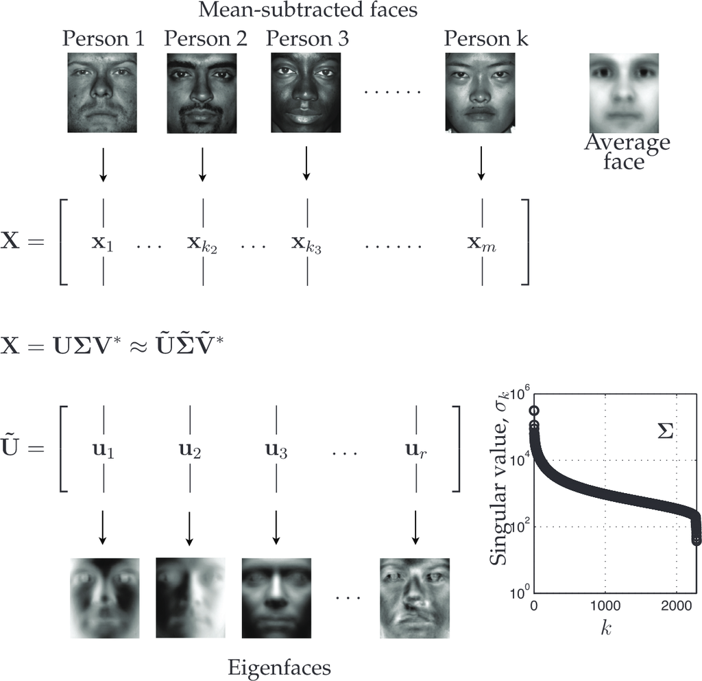

Eigenfaces and SVD (Brunton and Kutz 2019)

## Various SVD forms

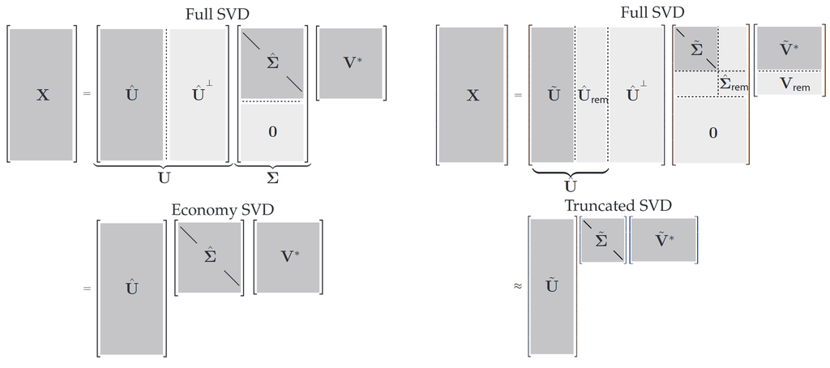

SVD forms (Brunton and Kutz 2019)

. . .

$$\begin{aligned}
X_\text{tr} \approx \hat X_\text{tr} &= U_\text{tr} \Sigma_\text{tr} V_\text{tr}^* = U_\text{tr} W_\text{tr}^* \\
X_\text{ts} \stackrel{\text{?}}{\approx} \hat X_\text{ts} &= U_\text{tr} (U_\text{tr}^* X_\text{ts}) \\
\end{aligned}$$
where $U$, $V$, and $\Sigma$ are from SVD (hat or tilde variations), and $W = \Sigma V^*$.

## Eigenfaces: Reconstructing Test Image

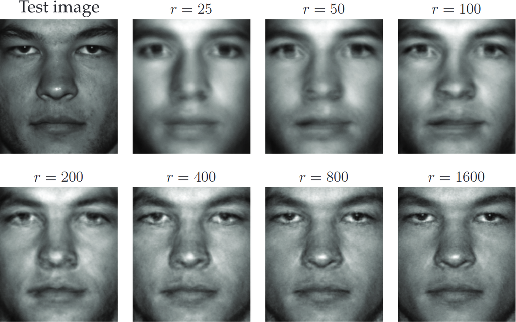

Face test image reconstruction (Brunton and Kutz 2019)

## Eigenfaces: Reconstructing Test Image

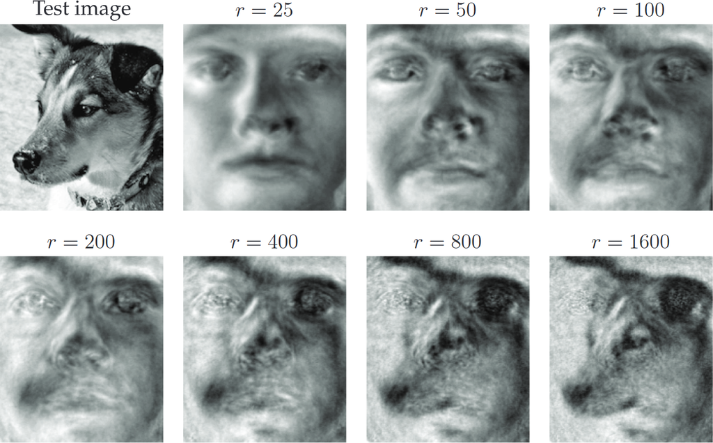

Dog test image reconstruction (Brunton and Kutz 2019)

## Eigenfaces: Reconstructing Test Image

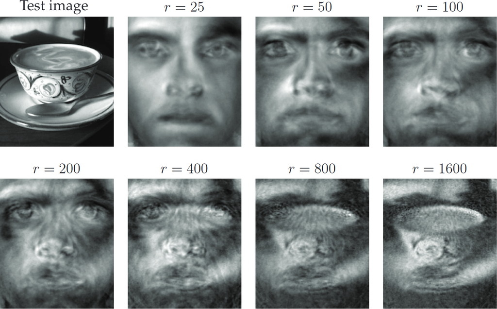

Cup test image reconstruction (Brunton and Kutz 2019)

## Non-negative Matrix Factorization

- Assume data $X$ is $p\times n$ matrix of non-negative values
- e.g., images, probabilities, counts, etc
- NMF computes the following factorization:
  $$\min_{W,H} \| X - WH \|_F\\
  \text{ subject to } W\geq 0,\ H\geq 0,$$
  where $W$ is ${p\times r}$ matrix and $H$ is ${r\times n}$ matrix consist of non-negative values.
- Each vectorized image is a column of $X$

## NMF for Image Analysis

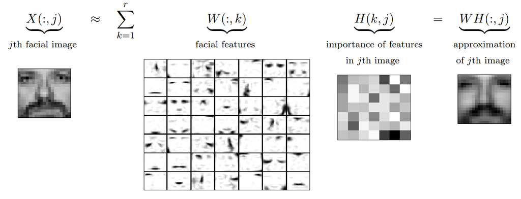

nmf-faces

## NMF for Hyperspectral image analysis

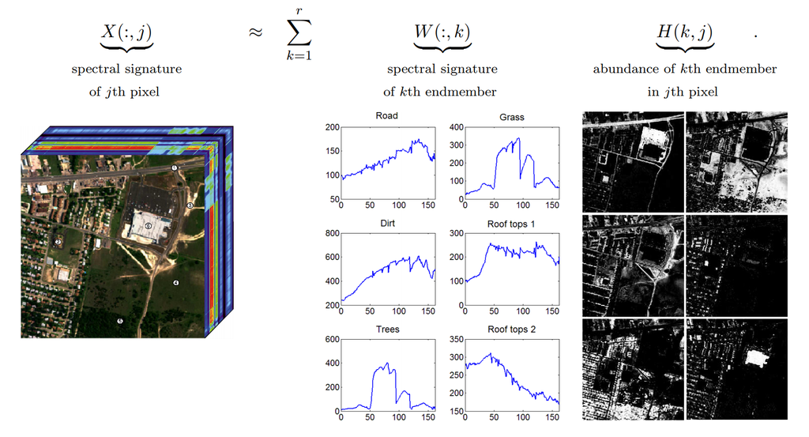

nmf-hyper

## NMF for Document Topic Discovery

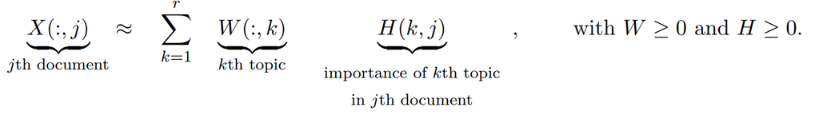

nmf-topics

## References

Brunton, Steven L., and J. Nathan Kutz. 2019. *Data-Driven Science and Engineering*. Cambridge University Press. https://doi.org/10.1017/9781108380690.

Calder, Jeff, and Peter J. Olver. 2025. *Linear Algebra, Data Science, and Machine Learning*. Springer Undergraduate Texts in Mathematics and Technology. Cham: Springer Nature Switzerland. https://doi.org/10.1007/978-3-031-93764-4.